# Age-regressed GAMM Interaction models

Bart

5/20/2019

# Age and other covariates regressed out of the brain and behavior measures. The residuals are used in the models.

## Relevant functions:

### GAMM modeling

```r
# This function:
# 1. executes the GAMM model,
# 2. sends output to the parametric bootstrap (if requested),
# 3. prints a regression table, and
# 4. sends the model to the visualizer for plotting.

gamm_model <- function(df, model_formula, this_label, smooth_var, int_var = NULL,weight_var = NULL,group_var, pbootstrap = F, longPlot = F, model_test = T){
  cat(sprintf("\n\n### Results for %s\n",this_label))
  if (is.null(weight_var)) {
    df$weight <- 1 #if no weighting variable is provided, weight all obs equally.
  } else {
    df$weight <- unlist(df[,weight_var]) # Use weight variable if provided.
  }

  model_formula <- as.formula(model_formula)
  if(!"exclusions" %in% colnames(df))  {
    df$exclusions <- FALSE; #there is no exclusions column so make one that excludes none
  }

  g1<-gamm(model_formula,
           data=df,
           random = list(bblid =~ 1),
           subset = exclusions == F,
           weights = weight)

  if (model_test == T){
    if (pbootstrap == T) {
      #Send to bootstrap function
      g1$pb<-pboot(g1)
      #Print a table that shows the bootstrap outcome
      print(g1$pb %>%
        summary() %>%
        .$test %>%
        as.data.frame() %>%
        kable(caption = sprintf("Parametric Bootstrap test for %s",this_label)) %>%
        kable_styling(full_width = F, position = "left",bootstrap_options = c("striped"))
      )

      if (isTRUE(all.equal(g1$pb$bestmod,model_formula))) {
        cat("The initial (more complicated) model is best")
        g <- g1

        #This next part is no longer implemented (refit the model using unfixed degrees of freedom). Effective part is commented out below.
        if (str_detect(deparse(model_formula),"F1_Social_Cognition_Efficiency") &this_label == "Right_Pallidum_male") {
          plot_formula <- model_formula
        } else {
        plot_formula <- as.formula(gsub(", fx = T","",deparse(model_formula)))
        }
        cat(deparse(plot_formula))
        plotg<-g
        # plotg <- gamm(plot_formula,
        #               data = df,
        #               random = list(bblid =~1),
        #               subset = exclusions == F)
      } else {
        cat("The simpler model is best")

        g <-gamm(as.formula(g1$pb$bestmod),
                 data=df,
                 random = list(bblid =~ 1),
                 subset = exclusions == F,
                 weights = weight)

        #Again, this part not implemented (model not refit with unfixed df)
        plot_formula <- as.formula(gsub("ti\\(",'te\\(',deparse(g$gam$formula)) %>% gsub(", fx = T", "", .))
        plotg<-g
        # plotg <-gamm(plot_formula,
        #          data=df,
        #          random = list(bblid =~ 1),
        #          subset = exclusions == F)
      }
    } else {
      if (!is.null(int_var)) {
        # We are not bootstrapping, but there is an interaction variable
        s<-summary(g1$gam)
        if (s$s.table[grep(x=rownames(s$s.table),pattern = int_var),"p-value"] <.05)  {
          #Checked if interaction is sig, if so keep in the model
          g <- g1
          plot_formula <- as.formula(gsub(", fx = T", "", deparse(model_formula)))
          plotg <- g
        } else {
          #Interaction is not sig, remove from the model
          cat("The simpler model is best")
          thisResp <- as.character(g1$gam$terms[[2]])
          theseVars <- attr(terms(model_formula),"term.labels")
          new_formula <- reformulate(theseVars[0:(length(theseVars)-1)],response = thisResp)

          g <-gamm(as.formula(new_formula),
                   data=df,
                   random = list(bblid =~ 1),
                   subset = exclusions == F,
                   weights = weight)
          plot_formula <- as.formula(gsub("ti\\(",'te\\(',deparse(g$gam$formula)) %>% gsub(", fx = T", "", .))
          plotg<-g
      }
      } else {
        #There is no interaction term, just plot.
        g <- g1
          plot_formula <- as.formula(gsub(", fx = T", "", deparse(model_formula)))
          plotg <- g
      }
    }
  } else {
    g <- g1
    plotg<-g
  }

  g$gam$data<-df %>%
    filter(exclusions == F)

  #Display model results:

  s_tidytable<- tidy(g$gam)
  p_tidytable <- tidy(g$gam,parametric = T)
  snames = names(s_tidytable)
  pnames = names(p_tidytable)
  names(s_tidytable)=pnames
  thisBIC <- BIC(g$lme)
  numObs <- g$lme$dims$N
  g$BIC <- thisBIC
  stattable <- rbind(p_tidytable,snames,s_tidytable) %>%
    kable(caption = sprintf("Regression table from gamm in %s, BIC = %1.2f, obs = %d",this_label,thisBIC,numObs)) %>%
    kable_styling(full_width = F, position = "left")
  print(stattable)

  #Send final model to visualizer:
  if (s_tidytable$p.value[nrow(s_tidytable)]<.05) {
    if (longPlot == T) {
      g$pl <- longitudinal_plot(g,plabels = this_label)
    } else {
      g$pl <- visualize_models(plotg,plabels = this_label, smooth_var = smooth_var, int_var = int_var, group_var = group_var)
    }
  }
  #Return result object
  result <- g

  return(result)
}
```

### Bootstrap procedure

This procedure is lifted from https://github.com/PennBBL/groupAnalysis/wiki/Model-Comparison-Using-Parametric-Bootstrap

```r
## Parametric bootstrap of likelihood ratio test for nested models
pboot <- function(modelobj){
  numsims <- 500

  df <- modelobj$gam$model
  thisResp <- as.character(modelobj$gam$terms[[2]])
  f1 <- modelobj$gam$formula
  theseVars <- attr(terms(f1),"term.labels")
  f2 <- reformulate(theseVars[0:(length(theseVars)-1)],response = thisResp)

  g1 <- gam(f1,data = df,weights = `(weights)`)
  g2 <- gam(f2,data = df,weights = `(weights)`)

  mat1 <- model.matrix(g1)
  mat2 <- model.matrix(g2)

  bblid<-df$bblid
  y <- df[,thisResp]
  w <- unlist(df[,"(weights)"])

  m1 <- lmer(y ~ -1 + mat1 + (1|bblid),weights = w)
  m2 <- lmer(y ~ -1 + mat2 + (1|bblid),weights = w)
  refdist <- PBrefdist(m1, m2, nsim=numsims)#, cl=cl)
  pb <- PBmodcomp(m1, m2, ref = refdist)
  int_pval <- pb$test["PBtest","p.value"]
  if (int_pval < .05) {
    pb$bestmod <- f1
  } else {
    pb$bestmod <- f2
  }
  return(pb)
}
```

## Cognitive Variables

Run the models:

```r
cog_vars <- c("NAR_Overall_Accuracy","NAR_Overall_Efficiency","NAR_F1_Social_Cognition_Efficiency","mpraxis_mp2rtcr")

for (brain_var in c("Accumbens_Area","Putamen","Caudate","Pallidum")) {
  cat(brain_var)
  thisTab <- dataTable %>% filter(scan2cnbmonths<6)
  g<-gamm(as.formula(sprintf("%s ~ sex + sequence + timepoint + s(age, k=4)",brain_var)),
           data=thisTab,
           random = list(bblid =~ 1))
  varname <- sprintf("%s_AR",brain_var)
  modtab <- g$gam$model %>% select(bblid,age)
  modtab[,varname] <- residuals.gam(g$gam,type = "pearson")
  thisTab <- left_join(thisTab,modtab,by = c("bblid","age"))

  for (beh_var in cog_vars) {
    cat(beh_var)

    g<-gamm(as.formula(sprintf("%s ~ sex + sequence + timepoint+ s(age, k=4)",beh_var)),
             data=thisTab,
             random = list(bblid =~ 1))
    beh_varname <- sprintf("%s_AR",beh_var)
    modtab <- g$gam$model %>% select(bblid,age)
    modtab[,beh_varname] <- residuals.gam(g$gam,type = "pearson")
    thisTab <- left_join(thisTab,modtab,by = c("bblid","age"))

    ar_gamm <- gamm(as.formula(sprintf("%s ~ s(%s,k=4)",varname,beh_varname)),
             data=thisTab,
             random = list(bblid =~ 1))
    cat(sprintf("\n\n### Results for %s",beh_var, brain_var))
    s_tidytable<- tidy(ar_gamm$gam)%>%
      kable(caption = sprintf("Regression table from gamm %s ~ %s",brain_var, beh_var)) %>%
      kable_styling(full_width = F, position = "left")
    print(s_tidytable)
    b <- getViz(ar_gamm$gam)
    var_plot <- plot(b,allTerms = T) +
      l_ciPoly() +
      l_fitRaster() + l_fitContour() +
      l_points() +  l_ciBar() +
      l_fitPoints(size = 1, col = 2) + l_fitLine()
    print(var_plot,pages = 1)

    ar2_gamm <- gamm(as.formula(sprintf("%s ~ s(%s,k=4) + s(%s, by = age ,k=4)",varname,beh_varname,beh_varname)),
             data=thisTab,
             random = list(bblid =~ 1))
    cat(sprintf("\n\n### Results2 for %s %s",beh_var, brain_var))
    s_tidytable<- tidy(ar_gamm$gam)%>%
      kable(caption = sprintf("Regression table from gamm %s ~ %s by age",brain_var, beh_var)) %>%
      kable_styling(full_width = F, position = "left")
    print(s_tidytable)
    b <- getViz(ar_gamm$gam)
    var_plot <- plot(b,allTerms = T) +
      l_ciPoly() +
      l_fitRaster() + l_fitContour() +
      l_points() +  l_ciBar() +
      l_fitPoints(size = 1, col = 2) + l_fitLine()
    print(var_plot,pages = 1)
  }
}
```

Accumbens_AreaNAR_Overall_Accuracy

### Results for NAR_Overall_Accuracy

Regression table from gamm Accumbens_Area ~ NAR_Overall_Accuracy

| term | edf | ref.df | statistic | p.value |
| --- | --- | --- | --- | --- |
| s(NAR_Overall_Accuracy_AR) | 1 | 1 | 0.015108 | 0.9021938 |

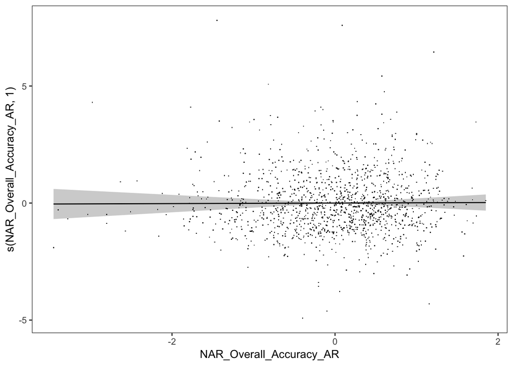

### Results2 for NAR_Overall_Accuracy Accumbens_Area

Regression table from gamm Accumbens_Area ~ NAR_Overall_Accuracy by age

| term | edf | ref.df | statistic | p.value |
| --- | --- | --- | --- | --- |
| s(NAR_Overall_Accuracy_AR) | 1 | 1 | 0.015108 | 0.9021938 |

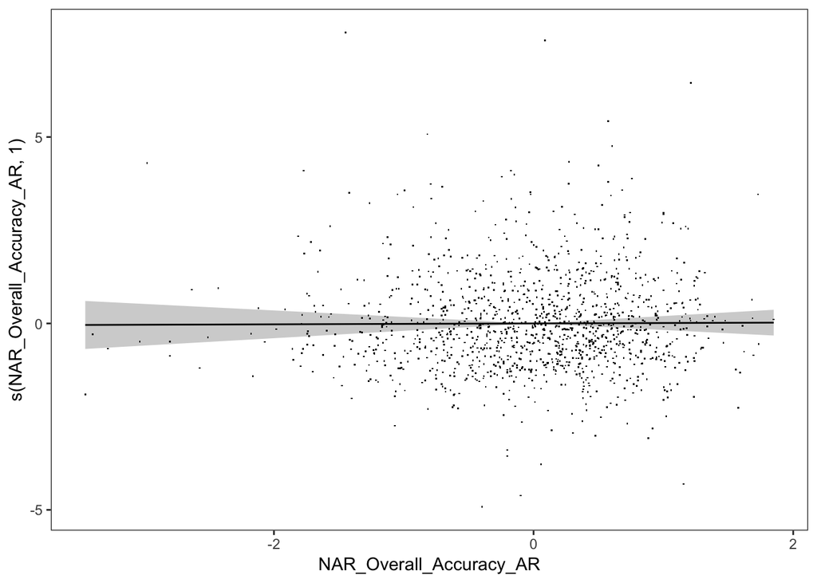

NAR_Overall_Efficiency

### Results for NAR_Overall_Efficiency

Regression table from gamm Accumbens_Area ~ NAR_Overall_Efficiency

| term | edf | ref.df | statistic | p.value |
| --- | --- | --- | --- | --- |
| s(NAR_Overall_Efficiency_AR) | 1.000001 | 1.000001 | 0.0948289 | 0.7581747 |

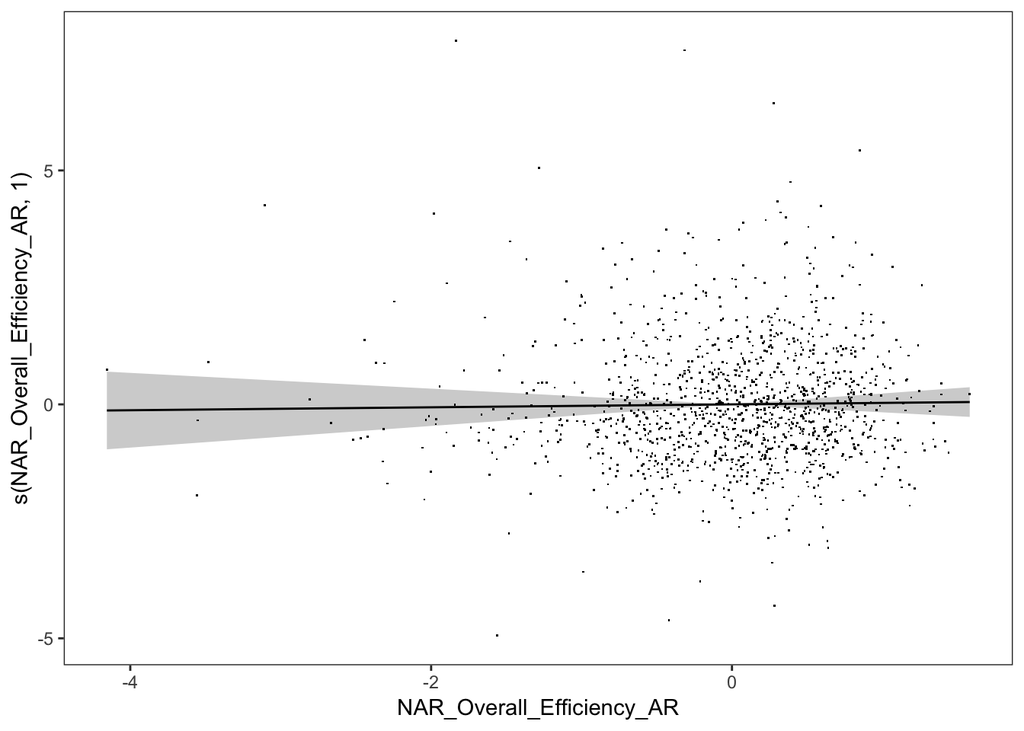

### Results2 for NAR_Overall_Efficiency Accumbens_Area

Regression table from gamm Accumbens_Area ~ NAR_Overall_Efficiency by age

| term | edf | ref.df | statistic | p.value |
| --- | --- | --- | --- | --- |
| s(NAR_Overall_Efficiency_AR) | 1.000001 | 1.000001 | 0.0948289 | 0.7581747 |

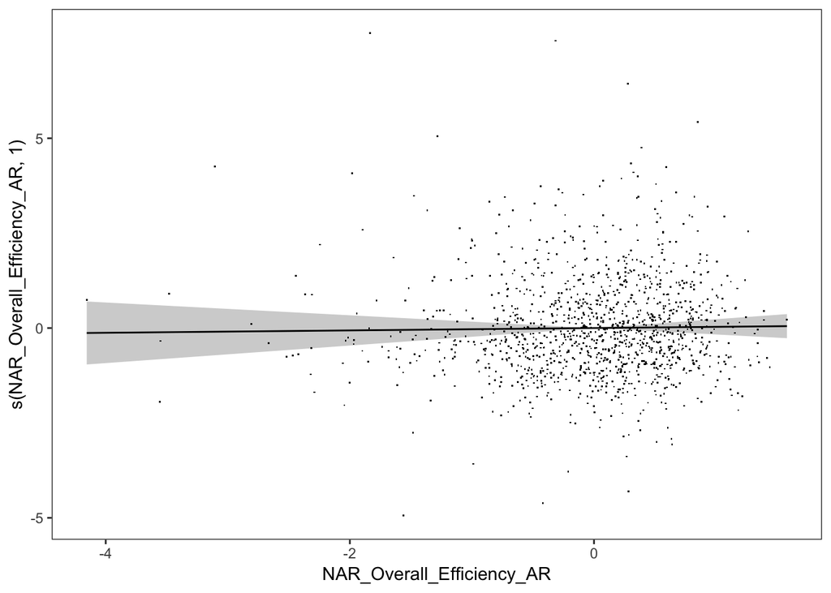

NAR_F1_Social_Cognition_Efficiency

### Results for NAR_F1_Social_Cognition_Efficiency

Regression table from gamm Accumbens_Area ~ NAR_F1_Social_Cognition_Efficiency

| term | edf | ref.df | statistic | p.value |
| --- | --- | --- | --- | --- |
| s(NAR_F1_Social_Cognition_Efficiency_AR) | 1 | 1 | 0.3726152 | 0.5416891 |

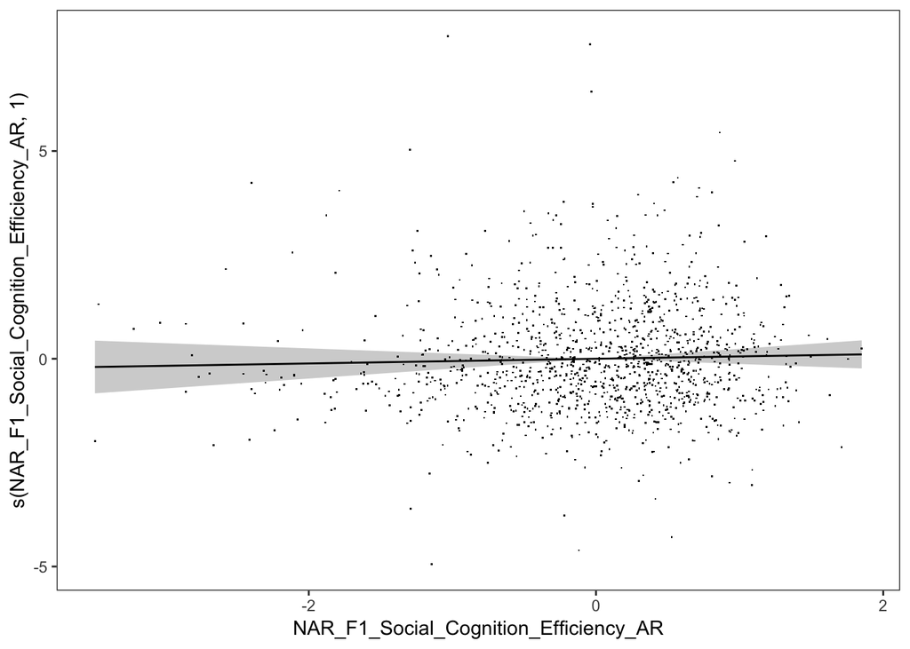

### Results2 for NAR_F1_Social_Cognition_Efficiency Accumbens_Area

Regression table from gamm Accumbens_Area ~ NAR_F1_Social_Cognition_Efficiency by age

| term | edf | ref.df | statistic | p.value |
| --- | --- | --- | --- | --- |
| s(NAR_F1_Social_Cognition_Efficiency_AR) | 1 | 1 | 0.3726152 | 0.5416891 |

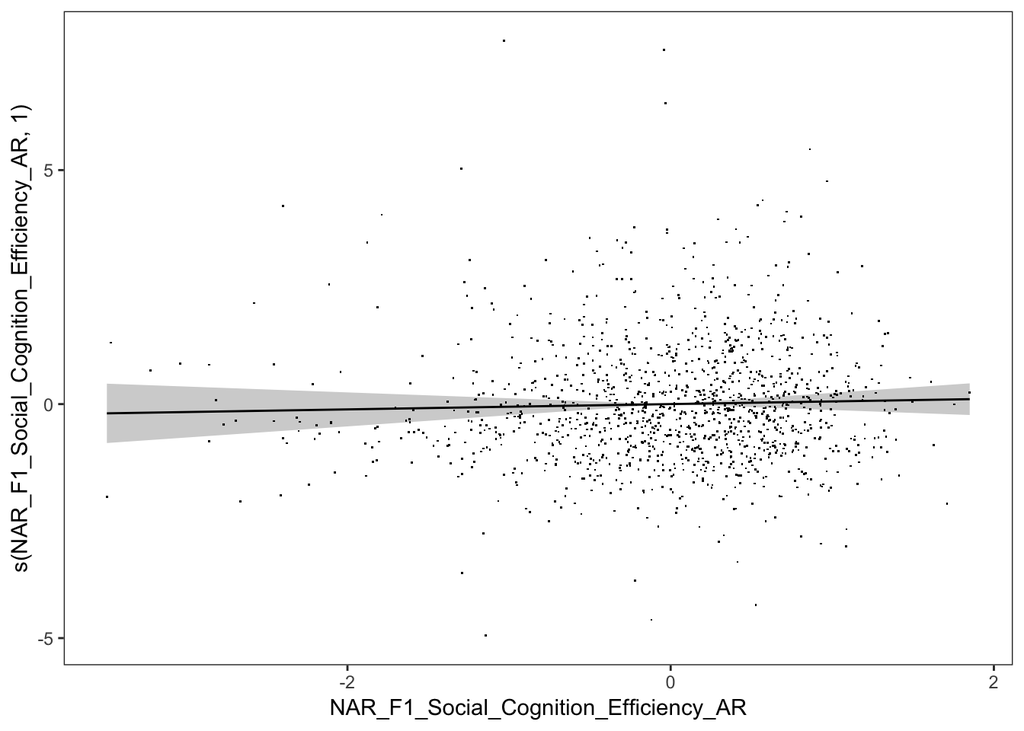

mpraxis_mp2rtcr

### Results for mpraxis_mp2rtcr

Regression table from gamm Accumbens_Area ~ mpraxis_mp2rtcr

| term | edf | ref.df | statistic | p.value |
| --- | --- | --- | --- | --- |
| s(mpraxis_mp2rtcr_AR) | 1 | 1 | 0.176887 | 0.6741318 |

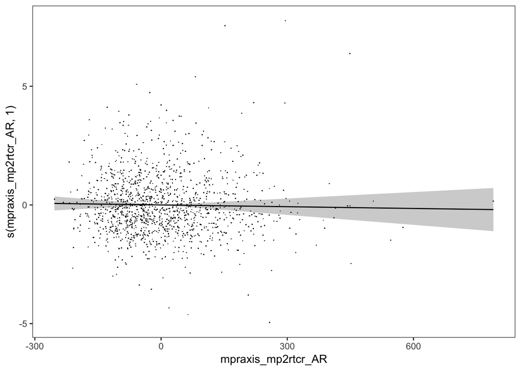

### Results2 for mpraxis_mp2rtcr Accumbens_Area

Regression table from gamm Accumbens_Area ~ mpraxis_mp2rtcr by age

| term | edf | ref.df | statistic | p.value |
| --- | --- | --- | --- | --- |
| s(mpraxis_mp2rtcr_AR) | 1 | 1 | 0.176887 | 0.6741318 |

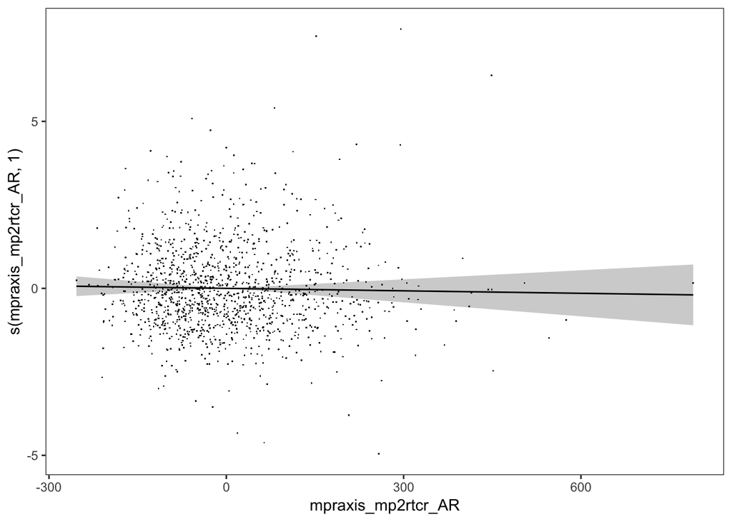

PutamenNAR_Overall_Accuracy

### Results for NAR_Overall_Accuracy

Regression table from gamm Putamen ~ NAR_Overall_Accuracy

| term | edf | ref.df | statistic | p.value |
| --- | --- | --- | --- | --- |
| s(NAR_Overall_Accuracy_AR) | 1 | 1 | 1.447506 | 0.2291453 |

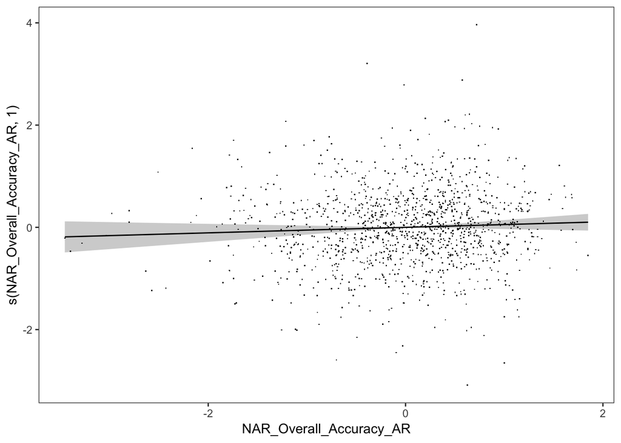

### Results2 for NAR_Overall_Accuracy Putamen

Regression table from gamm Putamen ~ NAR_Overall_Accuracy by age

| term | edf | ref.df | statistic | p.value |
| --- | --- | --- | --- | --- |
| s(NAR_Overall_Accuracy_AR) | 1 | 1 | 1.447506 | 0.2291453 |

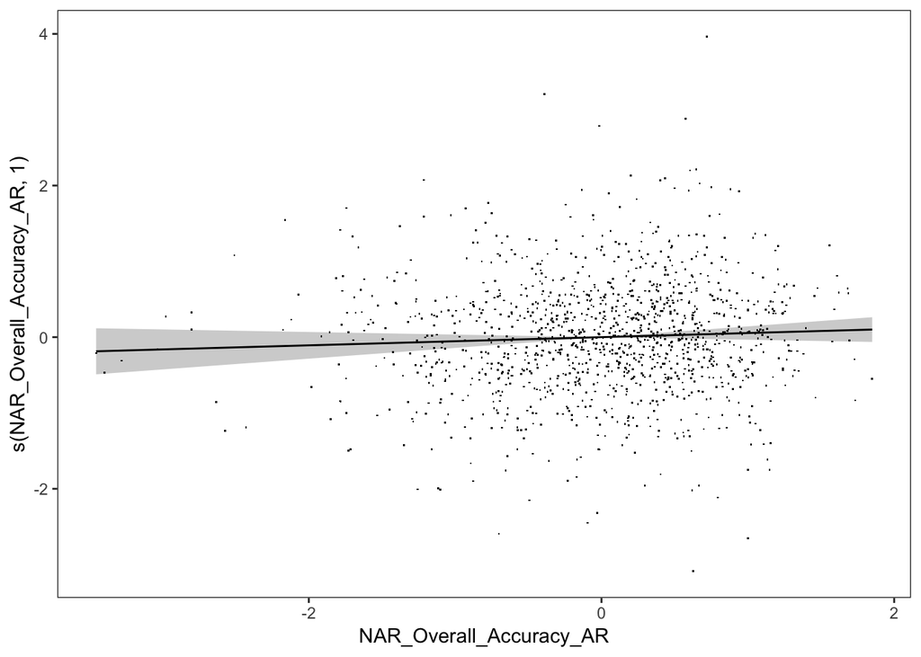

NAR_Overall_Efficiency

### Results for NAR_Overall_Efficiency

Regression table from gamm Putamen ~ NAR_Overall_Efficiency

| term | edf | ref.df | statistic | p.value |
| --- | --- | --- | --- | --- |
| s(NAR_Overall_Efficiency_AR) | 1.000001 | 1.000001 | 5.46485 | 0.0195508 |

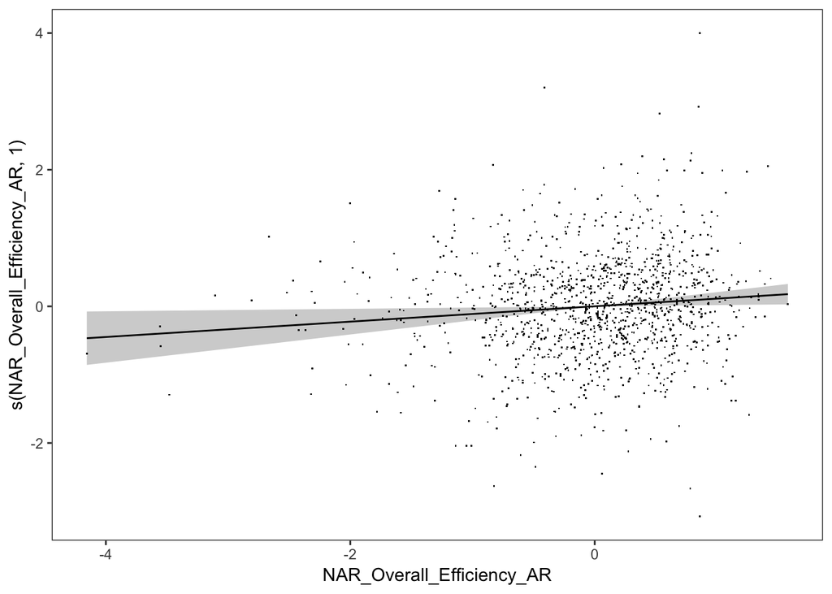

### Results2 for NAR_Overall_Efficiency Putamen

Regression table from gamm Putamen ~ NAR_Overall_Efficiency by age

| term | edf | ref.df | statistic | p.value |
| --- | --- | --- | --- | --- |
| s(NAR_Overall_Efficiency_AR) | 1.000001 | 1.000001 | 5.46485 | 0.0195508 |

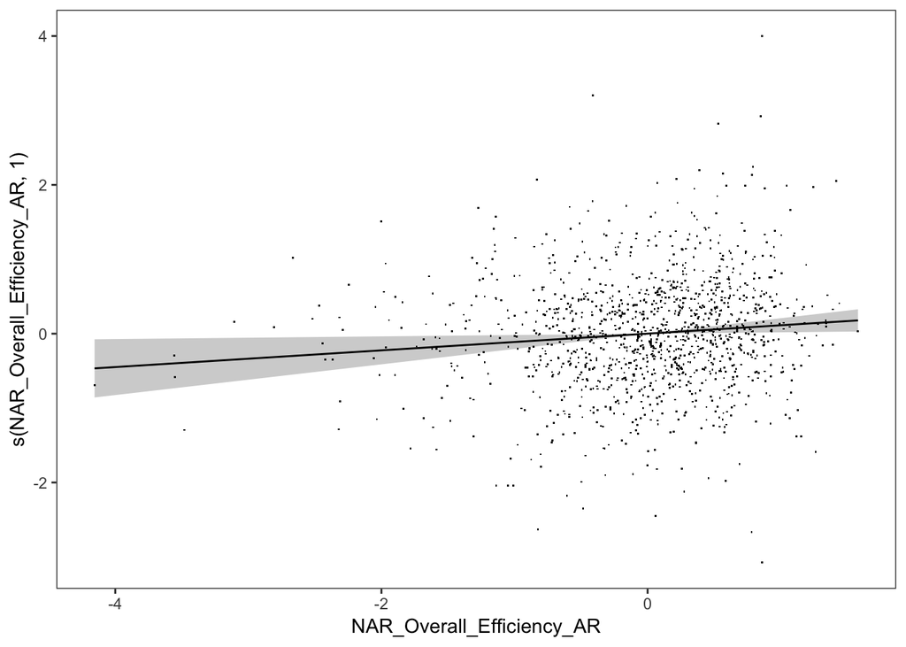

NAR_F1_Social_Cognition_Efficiency

### Results for NAR_F1_Social_Cognition_Efficiency

Regression table from gamm Putamen ~ NAR_F1_Social_Cognition_Efficiency

| term | edf | ref.df | statistic | p.value |
| --- | --- | --- | --- | --- |
| s(NAR_F1_Social_Cognition_Efficiency_AR) | 1.000001 | 1.000001 | 2.755639 | 0.0971495 |

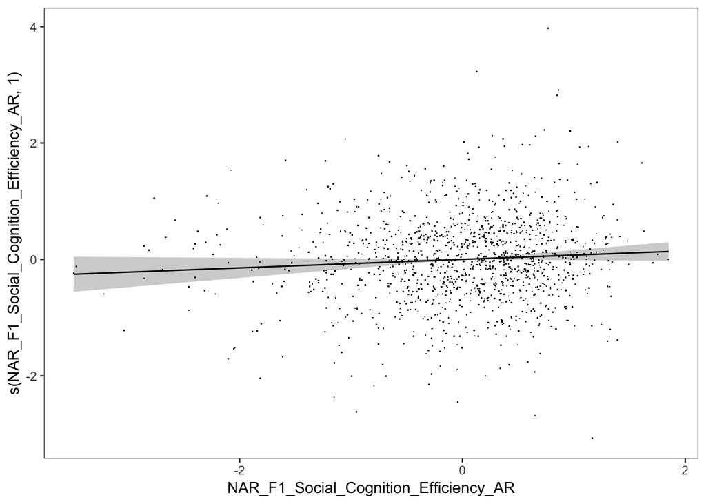

### Results2 for NAR_F1_Social_Cognition_Efficiency Putamen

Regression table from gamm Putamen ~ NAR_F1_Social_Cognition_Efficiency by age

| term | edf | ref.df | statistic | p.value |
| --- | --- | --- | --- | --- |
| s(NAR_F1_Social_Cognition_Efficiency_AR) | 1.000001 | 1.000001 | 2.755639 | 0.0971495 |

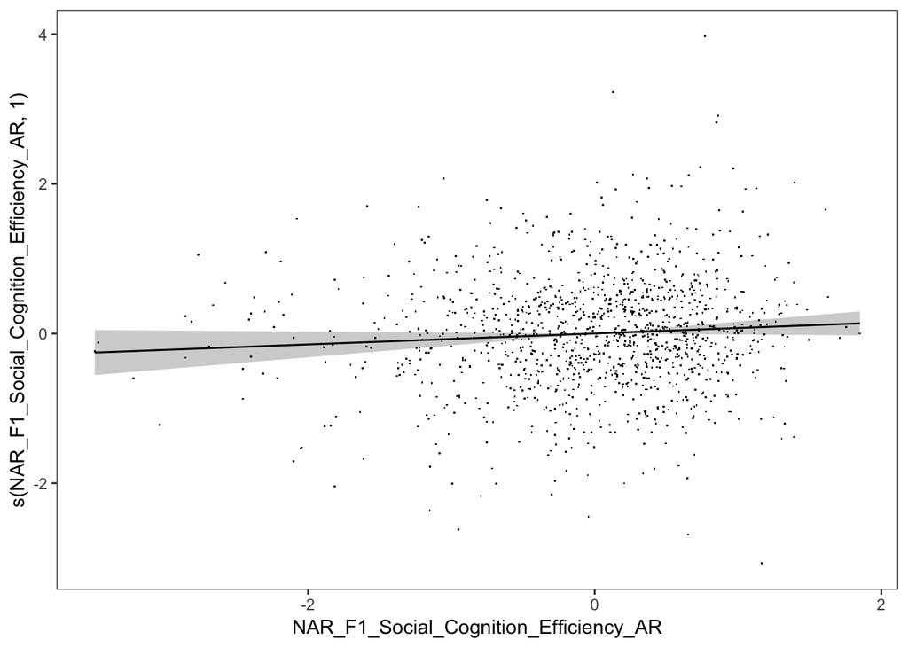

mpraxis_mp2rtcr

### Results for mpraxis_mp2rtcr

Regression table from gamm Putamen ~ mpraxis_mp2rtcr

| term | edf | ref.df | statistic | p.value |
| --- | --- | --- | --- | --- |
| s(mpraxis_mp2rtcr_AR) | 2.50566 | 2.50566 | 2.291927 | 0.0591282 |

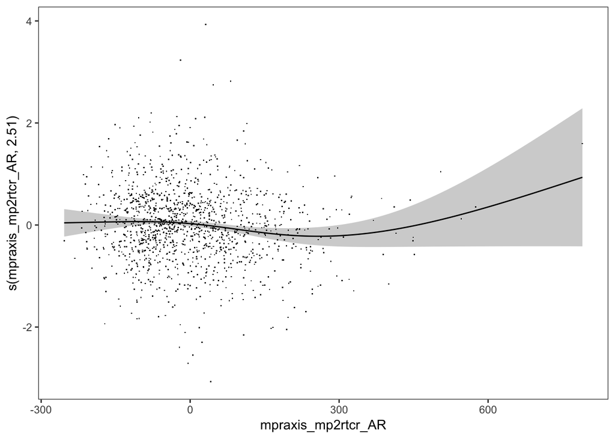

### Results2 for mpraxis_mp2rtcr Putamen

Regression table from gamm Putamen ~ mpraxis_mp2rtcr by age

| term | edf | ref.df | statistic | p.value |
| --- | --- | --- | --- | --- |
| s(mpraxis_mp2rtcr_AR) | 2.50566 | 2.50566 | 2.291927 | 0.0591282 |

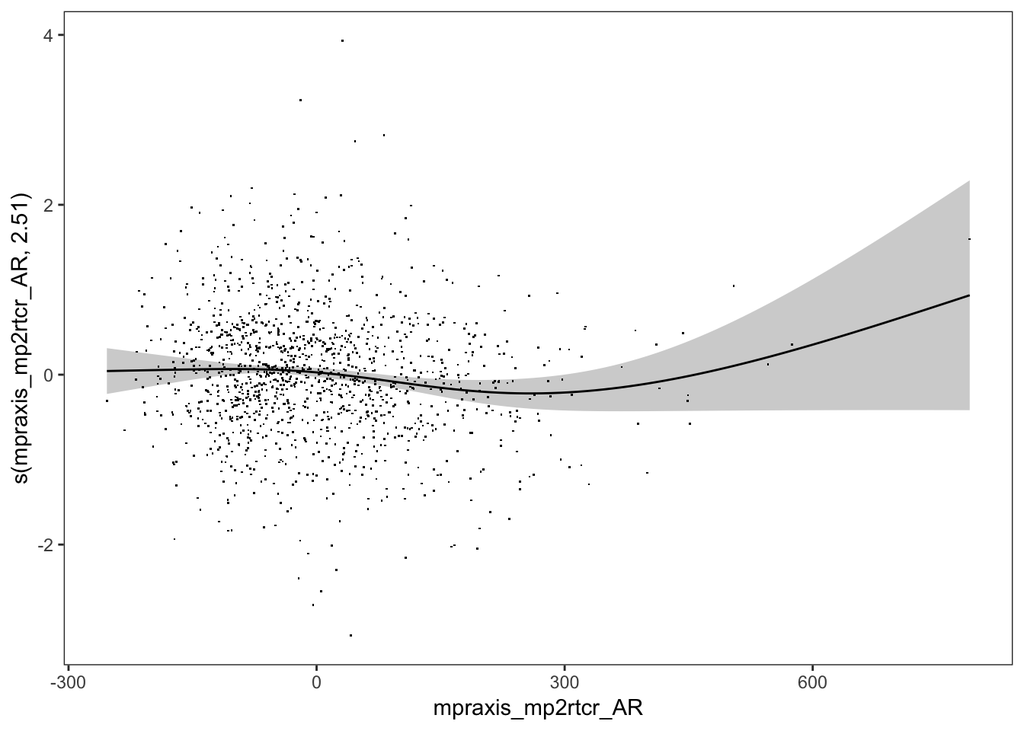

CaudateNAR_Overall_Accuracy

### Results for NAR_Overall_Accuracy

Regression table from gamm Caudate ~ NAR_Overall_Accuracy

| term | edf | ref.df | statistic | p.value |
| --- | --- | --- | --- | --- |
| s(NAR_Overall_Accuracy_AR) | 1 | 1 | 0.6566838 | 0.4178809 |

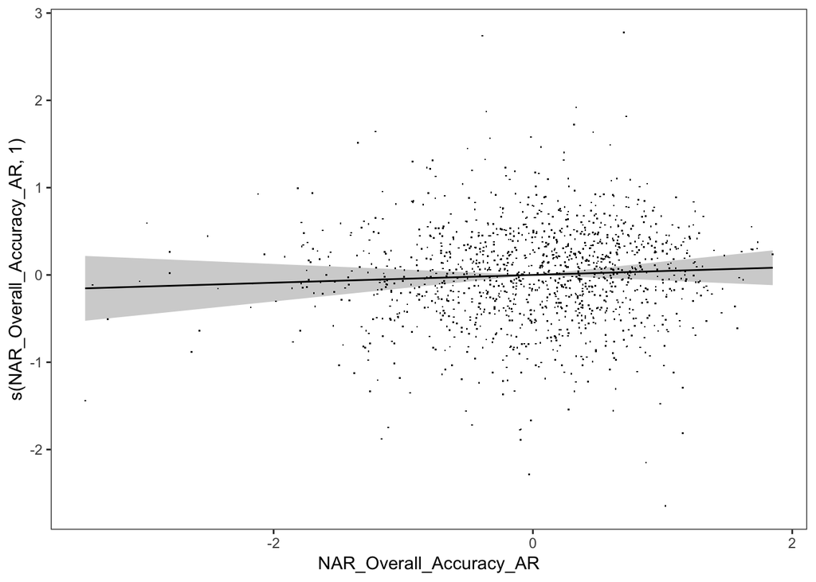

### Results2 for NAR_Overall_Accuracy Caudate

Regression table from gamm Caudate ~ NAR_Overall_Accuracy by age

| term | edf | ref.df | statistic | p.value |
| --- | --- | --- | --- | --- |
| s(NAR_Overall_Accuracy_AR) | 1 | 1 | 0.6566838 | 0.4178809 |

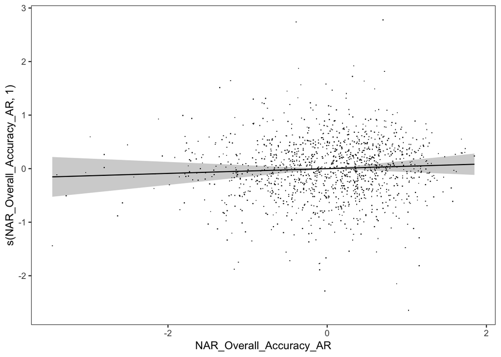

NAR_Overall_Efficiency

### Results for NAR_Overall_Efficiency

Regression table from gamm Caudate ~ NAR_Overall_Efficiency

| term | edf | ref.df | statistic | p.value |
| --- | --- | --- | --- | --- |
| s(NAR_Overall_Efficiency_AR) | 1.000001 | 1.000001 | 2.405579 | 0.1211431 |

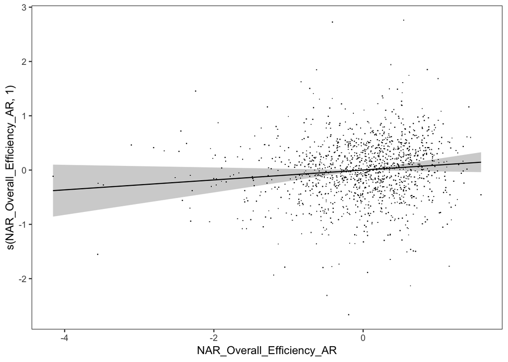

### Results2 for NAR_Overall_Efficiency Caudate

Regression table from gamm Caudate ~ NAR_Overall_Efficiency by age

| term | edf | ref.df | statistic | p.value |
| --- | --- | --- | --- | --- |
| s(NAR_Overall_Efficiency_AR) | 1.000001 | 1.000001 | 2.405579 | 0.1211431 |

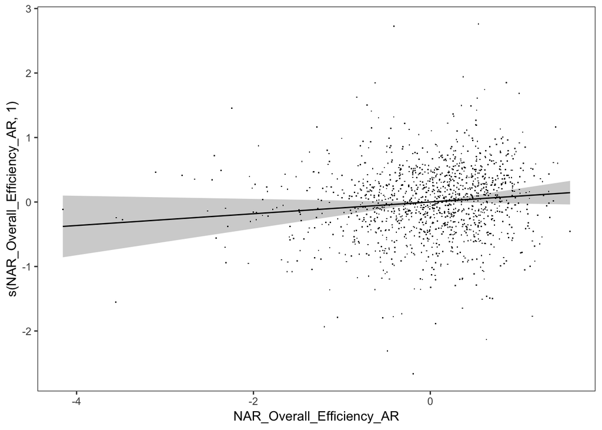

NAR_F1_Social_Cognition_Efficiency

### Results for NAR_F1_Social_Cognition_Efficiency

Regression table from gamm Caudate ~ NAR_F1_Social_Cognition_Efficiency

| term | edf | ref.df | statistic | p.value |
| --- | --- | --- | --- | --- |
| s(NAR_F1_Social_Cognition_Efficiency_AR) | 1 | 1 | 4.008887 | 0.0454647 |

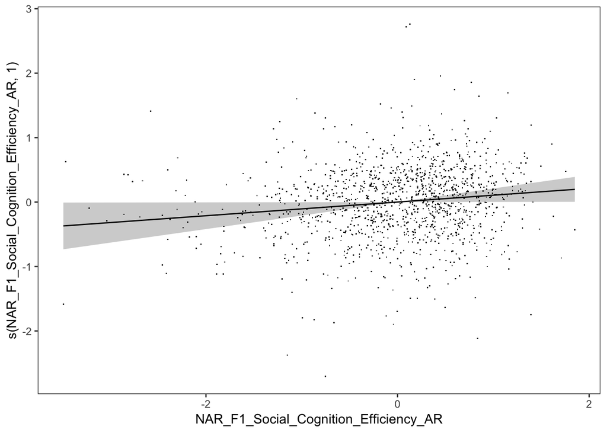

### Results2 for NAR_F1_Social_Cognition_Efficiency Caudate

Regression table from gamm Caudate ~ NAR_F1_Social_Cognition_Efficiency by age

| term | edf | ref.df | statistic | p.value |
| --- | --- | --- | --- | --- |
| s(NAR_F1_Social_Cognition_Efficiency_AR) | 1 | 1 | 4.008887 | 0.0454647 |

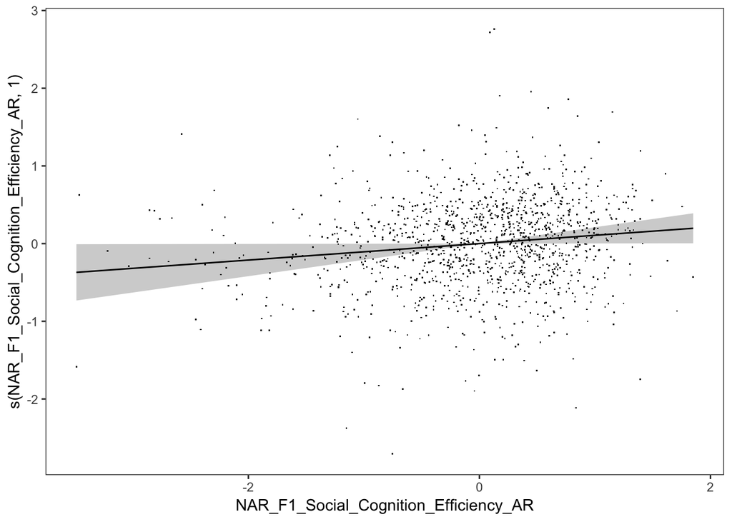

mpraxis_mp2rtcr

### Results for mpraxis_mp2rtcr

Regression table from gamm Caudate ~ mpraxis_mp2rtcr

| term | edf | ref.df | statistic | p.value |
| --- | --- | --- | --- | --- |
| s(mpraxis_mp2rtcr_AR) | 1 | 1 | 1.580915 | 0.2088521 |

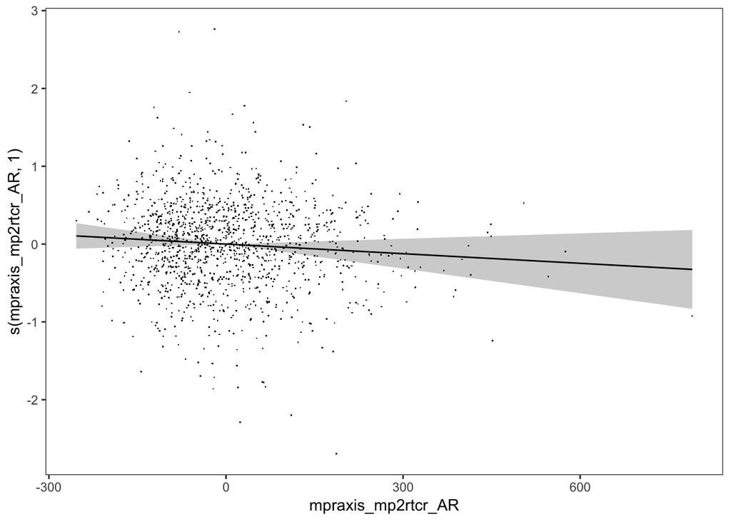

### Results2 for mpraxis_mp2rtcr Caudate

Regression table from gamm Caudate ~ mpraxis_mp2rtcr by age

| term | edf | ref.df | statistic | p.value |
| --- | --- | --- | --- | --- |
| s(mpraxis_mp2rtcr_AR) | 1 | 1 | 1.580915 | 0.2088521 |

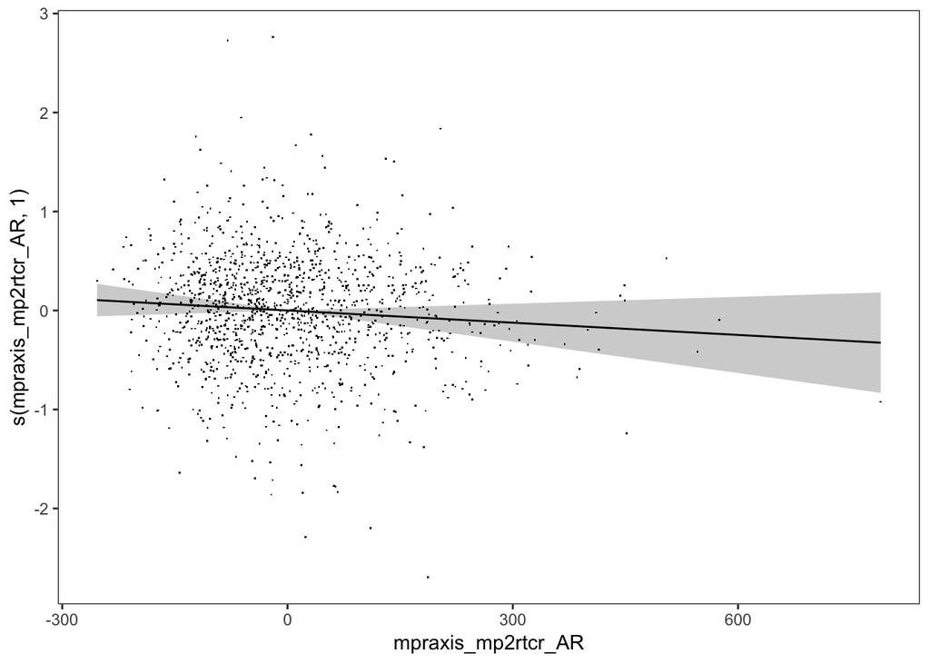

PallidumNAR_Overall_Accuracy

### Results for NAR_Overall_Accuracy

Regression table from gamm Pallidum ~ NAR_Overall_Accuracy

| term | edf | ref.df | statistic | p.value |
| --- | --- | --- | --- | --- |
| s(NAR_Overall_Accuracy_AR) | 1 | 1 | 0.719993 | 0.3963016 |

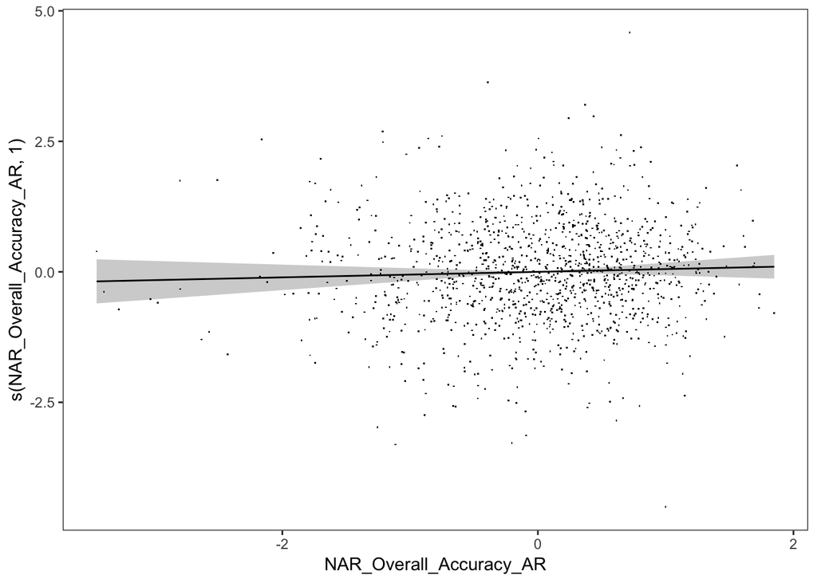

### Results2 for NAR_Overall_Accuracy Pallidum

Regression table from gamm Pallidum ~ NAR_Overall_Accuracy by age

| term | edf | ref.df | statistic | p.value |
| --- | --- | --- | --- | --- |
| s(NAR_Overall_Accuracy_AR) | 1 | 1 | 0.719993 | 0.3963016 |

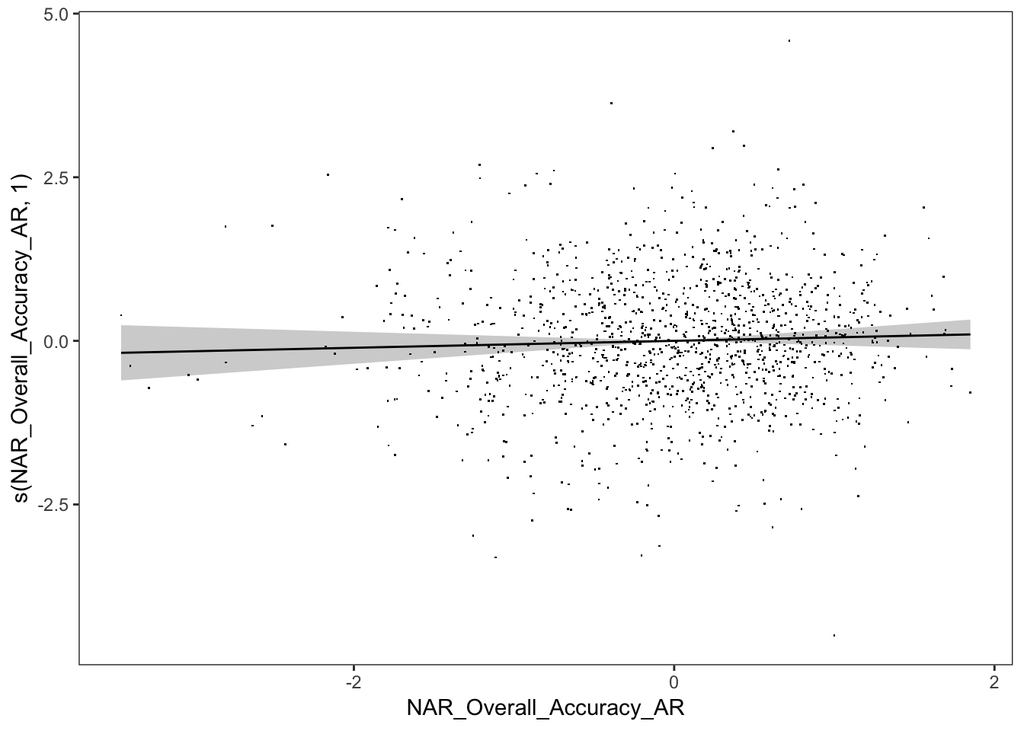

NAR_Overall_Efficiency

### Results for NAR_Overall_Efficiency

Regression table from gamm Pallidum ~ NAR_Overall_Efficiency

| term | edf | ref.df | statistic | p.value |
| --- | --- | --- | --- | --- |
| s(NAR_Overall_Efficiency_AR) | 1 | 1 | 1.251952 | 0.2633846 |

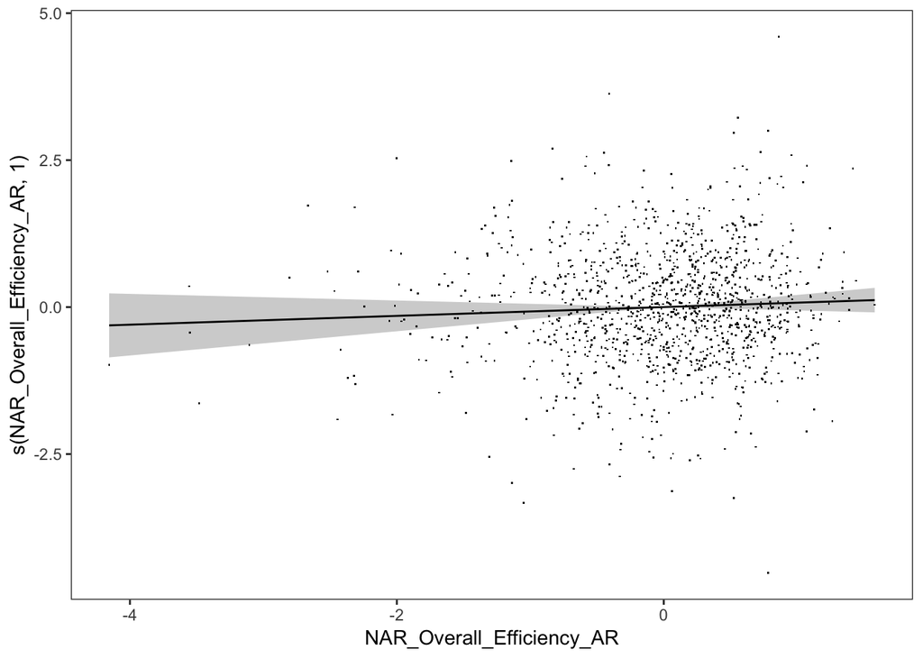

### Results2 for NAR_Overall_Efficiency Pallidum

Regression table from gamm Pallidum ~ NAR_Overall_Efficiency by age

| term | edf | ref.df | statistic | p.value |
| --- | --- | --- | --- | --- |
| s(NAR_Overall_Efficiency_AR) | 1 | 1 | 1.251952 | 0.2633846 |

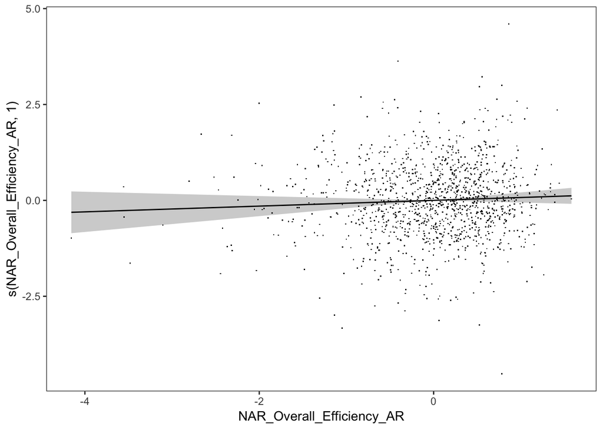

NAR_F1_Social_Cognition_Efficiency

### Results for NAR_F1_Social_Cognition_Efficiency

Regression table from gamm Pallidum ~ NAR_F1_Social_Cognition_Efficiency

| term | edf | ref.df | statistic | p.value |
| --- | --- | --- | --- | --- |
| s(NAR_F1_Social_Cognition_Efficiency_AR) | 1 | 1 | 0.5463221 | 0.4599574 |

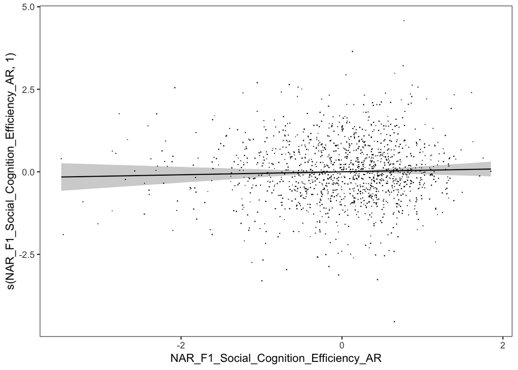

### Results2 for NAR_F1_Social_Cognition_Efficiency Pallidum

Regression table from gamm Pallidum ~ NAR_F1_Social_Cognition_Efficiency by age

| term | edf | ref.df | statistic | p.value |
| --- | --- | --- | --- | --- |
| s(NAR_F1_Social_Cognition_Efficiency_AR) | 1 | 1 | 0.5463221 | 0.4599574 |

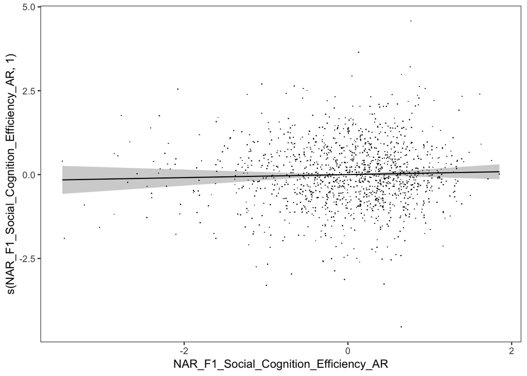

mpraxis_mp2rtcr

### Results for mpraxis_mp2rtcr

Regression table from gamm Pallidum ~ mpraxis_mp2rtcr

| term | edf | ref.df | statistic | p.value |
| --- | --- | --- | --- | --- |
| s(mpraxis_mp2rtcr_AR) | 2.653104 | 2.653104 | 2.129761 | 0.053183 |

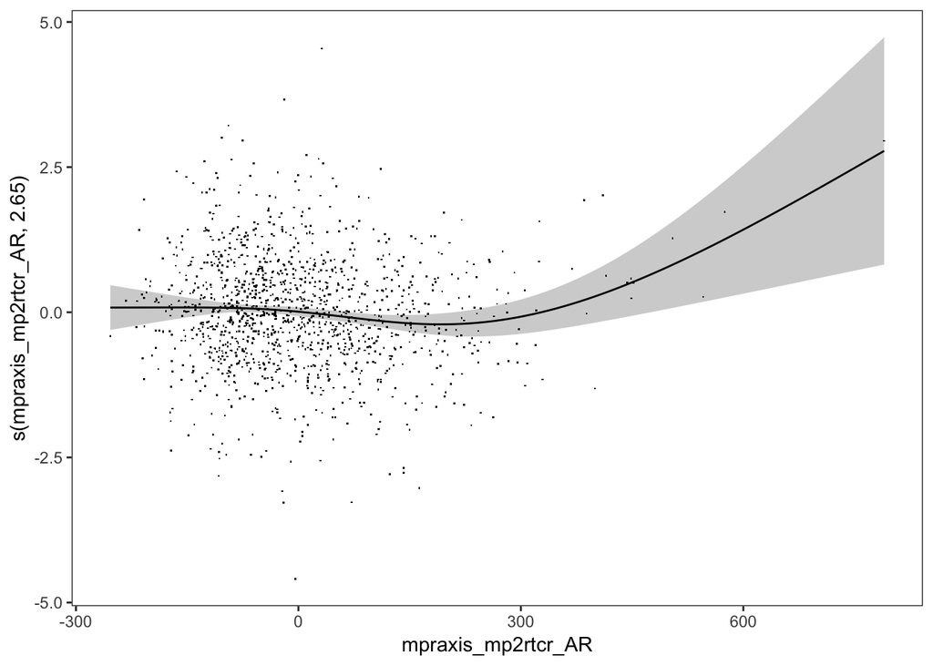

### Results2 for mpraxis_mp2rtcr Pallidum

Regression table from gamm Pallidum ~ mpraxis_mp2rtcr by age

| term | edf | ref.df | statistic | p.value |
| --- | --- | --- | --- | --- |
| s(mpraxis_mp2rtcr_AR) | 2.653104 | 2.653104 | 2.129761 | 0.053183 |

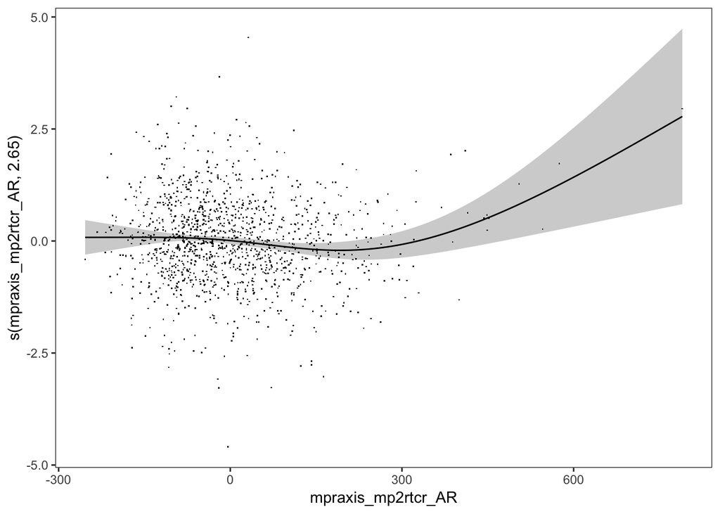